# Praxis Biostatistique M1C1

# Module 1

## Chapitre 1 : Régression linéaire simple avec une variable indépendante continue

### Syntaxe de l’exemple d’application présenté

Premièrement, vous devez télécharger appeler les packages nécessaires pour le premier chapitre. Si vous n’avez jamais téléchargé les packages, retirez les # avant les fonctions install.packages().

```r
# Si vous n'avez pas déjà téléchargé les packages, retirez le # des prochaines lignes.
#install.packages("tidyverse")
#install.packages("rsq")
#install.packages("ggplot2")
#install.packages("descr")

library (tidyverse)
library(rsq)
library(ggplot2)
library(descr)
```

```r
bd <- read.csv("C:/Users/Guill/Desktop/Team Lacourse/Praxis/Biostat/Base de données/Applications/bioM1C1")

bd # Lecture de la base de données
```

| X | weight | recov |
| --- | --- | --- |
| 1 | 60.0 | 13 |
| 2 | 182.4 | 10 |
| 3 | 62.4 | 14 |
| 4 | 62.4 | 11 |
| 5 | 82.8 | 14 |
| 6 | 44.4 | 10 |
| 7 | 61.2 | 9 |
| 8 | 64.8 | 11 |
| 9 | 87.6 | 19 |
| 10 | 58.8 | 14 |

[output cut: 41 more lines]

```r
attach(bd) # Attacher la base de données
```

Voici les variables à l’étude dans cet exemple :

recov : Nombre de jour pour se rétablir du virus de l’influenza  
weight: Le poids d’un individu en kilogrammes

Commençons par produire quelques statistiques descriptives de base pour se familiariser avec les variables à l’étude :

La moyenne  
La médiane  
Le minimum  
Le maximum  
L’écart-type

```r
#Statistiques descriptives

summary(recov)
```

```
##    Min. 1st Qu.  Median    Mean 3rd Qu.    Max.
##    4.00    9.00   10.00   10.35   12.00   19.00
```

```r
sd(recov)
```

```
## [1] 2.777218
```

```r
summary(weight)
```

```
##    Min. 1st Qu.  Median    Mean 3rd Qu.    Max.
##   32.40   48.00   58.80   60.19   66.00  182.40
```

```r
sd(weight)
```

```
## [1] 22.02041
```

Par la suite, nous produisons des histogrammes, pour vérifier si les variables respectent le postulat de normalité de distribution.

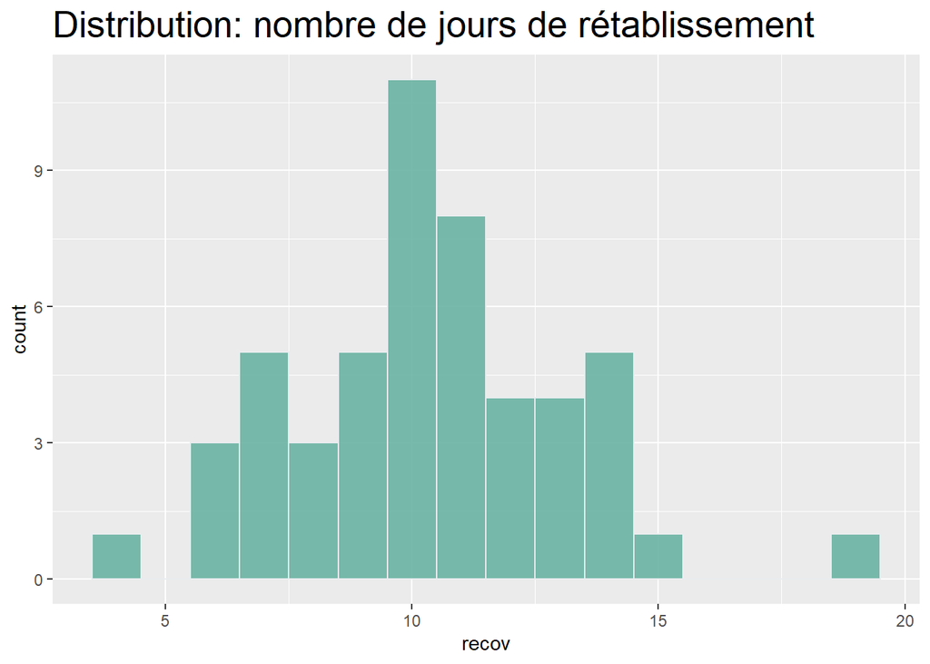

```r
#Histogramme pour vérification du postulat de normalité

ggplot(bd, aes(x=recov)) +
  geom_histogram(binwidth=1, fill="#69b3a2", color="#e9ecef", alpha=0.9) +
    ggtitle("Distribution: nombre de jours de rétablissement") +
    theme(
      plot.title = element_text(size=20)
    )
```

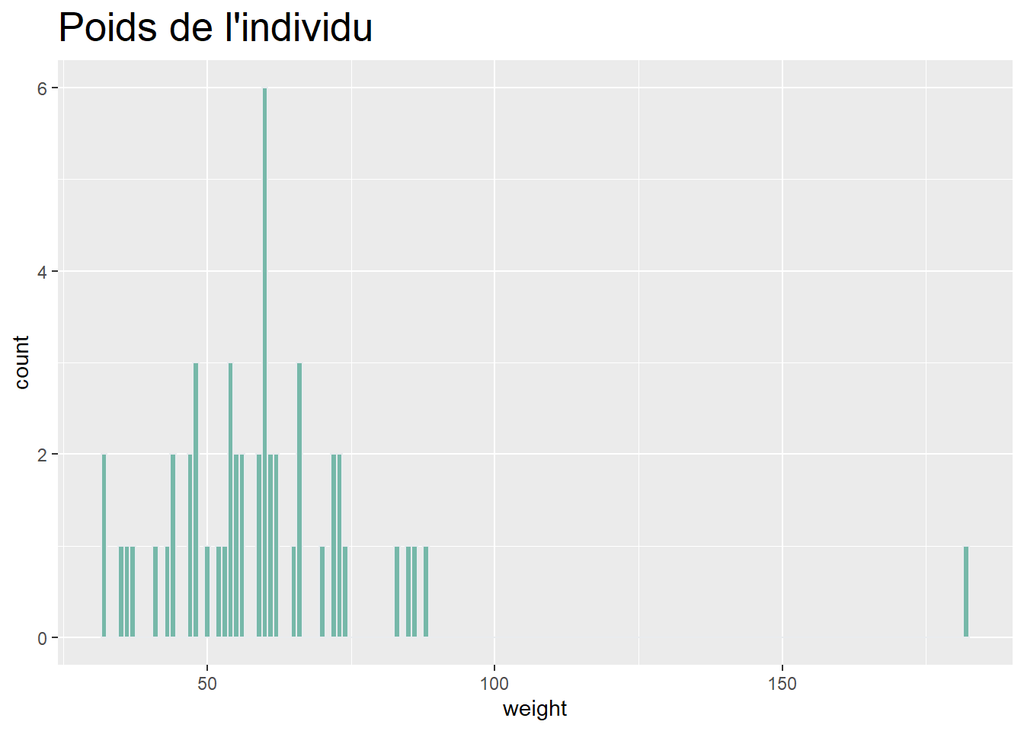

```r
ggplot(bd, aes(x=weight)) +
  geom_histogram(binwidth=1, fill="#69b3a2", color="#e9ecef", alpha=0.9) +
    ggtitle("Poids de l'individu") +
    theme(
      plot.title = element_text(size=20)
    )
```

Enfin, pour avoir un aperçu de la relation entre les variables, nous produisons un graphique de dispersion, ou nuage de points.  
On se sert également du nuage de points pour confirmer l’existence d’une donnée extrême et l’identifier plus précisément.

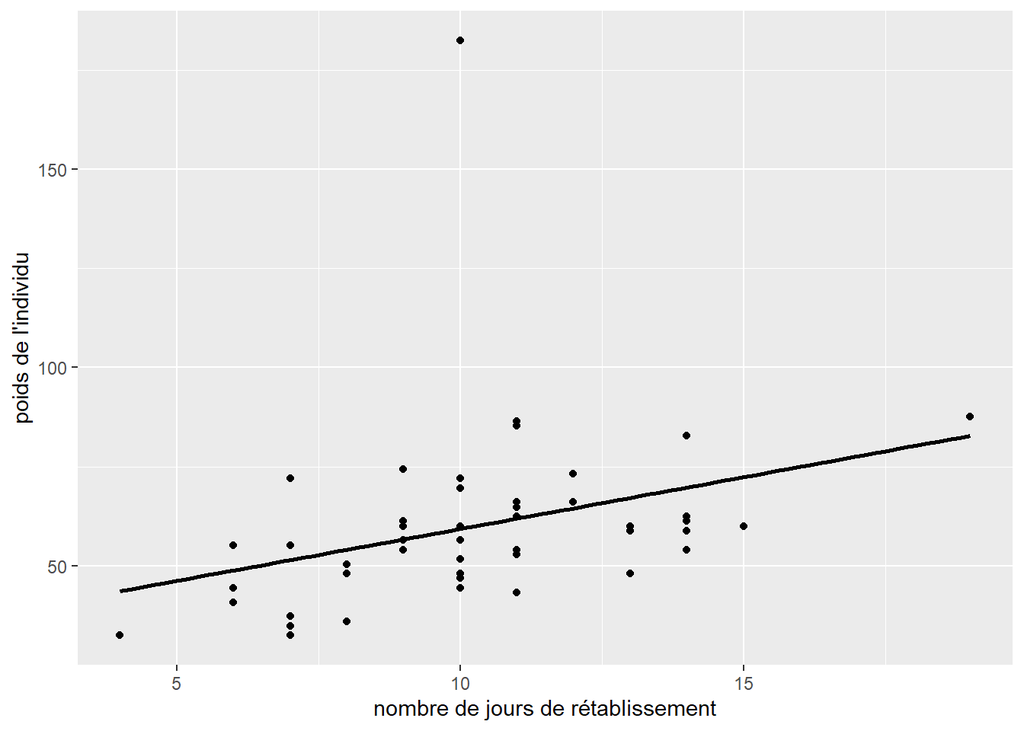

```r
#Nuage de points

nuage <- ggplot(bd, aes(x=recov, y=weight)) +
            geom_point() +
            geom_smooth(method=lm , color="black", se=FALSE)

nuage + labs(x = "nombre de jours de rétablissement", y = "poids de l'individu")
```

Interprétation:

Le nuage de point représente la relation entre le nombre de jours de rétablissement, la variable dépendante placée sur l’axe des X, et le poids de l’individu, la variable indépendante placée sur l’axe des Y. Chaque point représente un individu. On aperçoit une tendance générale positive, où le poids de l’individu augmente avec le nombre de jours de rétablissement. Donc plus le nombre de jour de rétablissement est élevé, plus le poids de l’individu l’est également et vice-versa. Toutefois, quelques points semblent s’éloigner du nuage de tendance générale, dont une donnée au sommet du graphique qui semble correspondre à une donnée extrême.  
Cette donnée extrême est tellement éloignée des autres qu’elle a assurément un impact important sur les résultats. Il faut donc la retirer; pour cela, il faut d’abord identifier à quel individu (observation) correspond ce point qu’on qualifie de donnée extrême.

Tout d’abord, on peut identifier les points directement dans le nuage de points pour savoir à quelle observation correspond notre point éloigné de la moyenne.

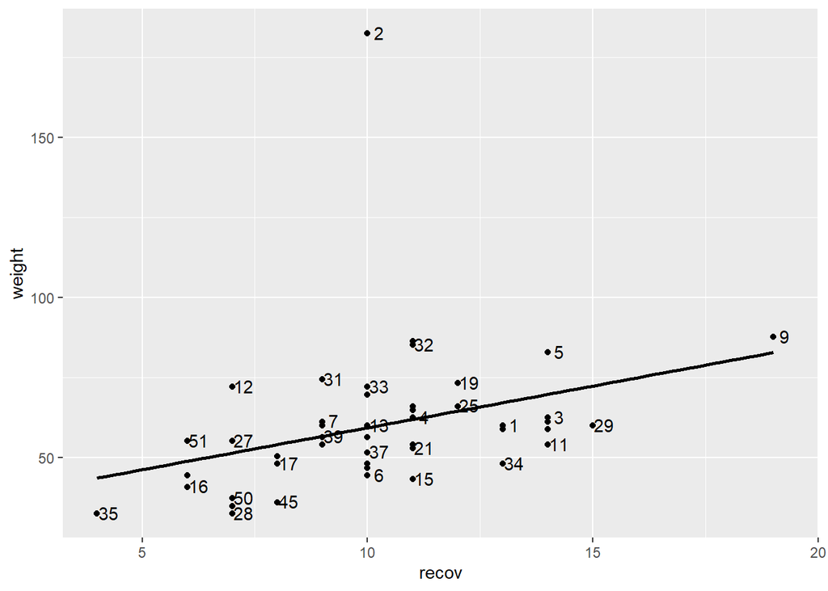

```r
#Identifier un point dans un graphique
nuage2 <- ggplot(bd, aes(x=recov, y=weight)) +
            geom_point() +
            geom_smooth(method=lm , color="black", se=FALSE) +
            geom_text(
               label=rownames(bd),
               nudge_x = 0.25, nudge_y = 0.25,
               check_overlap = T
            )

nuage2
```

Les données aberrantes ne sont pas toujours aussi évidentes à repérer, il existe deux méthodes plus efficaces pour les détecter.

On peut aussi identifier les données extrêmes à l’étape suivante, soit la réalisation de la régression linéaire en elle-même. Les statistiques de résidus standardisés produites avec la fonction rstandard nous permettent de déceler l’existence d’une donnée extrême dépassant l’intervalle de -3 à 3 écarts-types de la moyenne.

*Ne pas se fier aux “deviance residuals” produits automatiquement dans la régression linéaire : ceux-ci ne sont pas standardisés en fonction des écarts-types

```r
#Faire la régression linéaire

reglineaire <- glm(recov ~ weight, data = bd, family="gaussian")
summary(rstandard(reglineaire))
```

```
##      Min.   1st Qu.    Median      Mean   3rd Qu.      Max.
## -3.399656 -0.619069  0.001603 -0.026829  0.527787  2.909014
```

```r
summary(reglineaire)
```

```
##
## Call:
## glm(formula = recov ~ weight, family = "gaussian", data = bd)
##
## Deviance Residuals:
##     Min       1Q   Median       3Q      Max
## -5.4351  -1.6206   0.0042   1.3794   7.5072
##
## Coefficients:
##             Estimate Std. Error t value Pr(>|t|)
## (Intercept)  7.85005    1.08888   7.209 3.15e-09 ***
## weight       0.04158    0.01701   2.445   0.0181 *
## ---
## Signif. codes:  0 '***' 0.001 '**' 0.01 '*' 0.05 '.' 0.1 ' ' 1
##
## (Dispersion parameter for gaussian family taken to be 7.014717)
##
##     Null deviance: 385.65  on 50  degrees of freedom
## Residual deviance: 343.72  on 49  degrees of freedom
## AIC: 248.04
##
## Number of Fisher Scoring iterations: 2
```

```r
rsq(reglineaire)
```

```
## [1] 0.1087159
```

Il faut d’abord trouver quelle est l’observation qui s’éloigne autant de la moyenne. Une première méthode, applicable dans de petites bases de données, est de sortir les statistiques de résidus de chaque observation et de trouver celle(s) qui sortent de l’intervalle -3 à 3.

Évidemment, cette technique est longue et peu appropriée en présence d’un grand nombre d’observations. On peut donc identifier automatiquement les données extrêmes (outliers) en créant un objet qui contient toutes les observations dont les résidus excèdent l’intervalle de résidus acceptable. L’individu 2 (st=2) ressort comme étant notre donnée extrême.

```r
#Identification des résidus
rstandard(reglineaire)
```

```
##            1            2            3            4            5            6
##  1.012374747 -3.399656317  1.355781039  0.211688978  1.043438292  0.116383648
##            7            8            9           10           11           12
## -0.531965187  0.173687667  2.909013549  1.412784667  1.490042653 -1.470181950
##           13           14           15           16           17           18
## -0.131600430 -0.131600430  0.519287306 -1.363264082 -0.706173792  1.012374747
##           19           20           21           22           23           24
##  0.423244386 -0.743520880  0.364314750  0.078009228 -0.074536962 -1.416976733
##           25           26           27           28           29           30
##  0.536287263  0.345145704 -1.200088463 -0.851867584  1.775024865  0.078009228
##           31           32           33           34           35           36
## -0.744438169 -0.151888778 -0.322835433  1.206436098 -2.014889065 -0.512925490
##           37           38           39           40           41           42
##  0.001602529  0.154691267 -0.455976901  1.031444432  0.423244386 -0.888097650
##           43           44           45           46           47           48
##  1.374699745  0.536287263 -0.520118453 -0.418118928  0.058870164 -0.284359683
##           49           50           51
## -0.171400627 -0.924364066 -1.581612985
```

```r
outliers <- bd$weight[rstandard(reglineaire) < -3 | rstandard(reglineaire) > 3]
outliers
```

```
## [1] 182.4
```

Interprétation:

Avant le retrait des données extrêmes, la régression linéaire démontre l’existence d’une relation positive, de sorte que le nombre de jour de rétablissement augmente d’environ 0.04 pour chaque augmentation d’une unité du poids de l’individu. La relation est faible, mais positive et significative (p < 0.05). Selon le R-carré, environ 11% de la variance du nombre de jour de rétablissement est expliqué par le poids de l’individu.

```r
#Retrait de la donnée extrême
bd2 <- bd[-2, ]
bd2
```

|  | X | weight | recov |
| --- | --- | --- | --- |
| 1 | 1 | 60.0 | 13 |
| 3 | 3 | 62.4 | 14 |
| 4 | 4 | 62.4 | 11 |
| 5 | 5 | 82.8 | 14 |
| 6 | 6 | 44.4 | 10 |
| 7 | 7 | 61.2 | 9 |
| 8 | 8 | 64.8 | 11 |
| 9 | 9 | 87.6 | 19 |
| 10 | 10 | 58.8 | 14 |
| 11 | 11 | 54.0 | 14 |

[output cut: 40 more lines]

```r
#Retrait des données extrêmes (lorsqu'il y en a plusieurs)
bd3 <- bd [-outliers,]
bd3
```

|  | X | weight | recov |
| --- | --- | --- | --- |
| 1 | 1 | 60.0 | 13 |
| 2 | 2 | 182.4 | 10 |
| 3 | 3 | 62.4 | 14 |
| 4 | 4 | 62.4 | 11 |
| 5 | 5 | 82.8 | 14 |
| 6 | 6 | 44.4 | 10 |
| 7 | 7 | 61.2 | 9 |
| 8 | 8 | 64.8 | 11 |
| 9 | 9 | 87.6 | 19 |
| 10 | 10 | 58.8 | 14 |

[output cut: 41 more lines]

Maintenant que la donnée extrême est retirée, on refait simplement l’analyse de régression linéaire avec notre nouvelle base de données.

```r
#Refaire la régression linéaire sans les données extrêmes
reglineaire2 <- glm(recov ~ weight , data = bd2, family="gaussian")
summary(rstandard(reglineaire2))
```

```
##      Min.   1st Qu.    Median      Mean   3rd Qu.      Max.
## -2.195292 -0.688647 -0.075930 -0.002354  0.508451  2.347110
```

```r
summary(reglineaire2)
```

```
##
## Call:
## glm(formula = recov ~ weight, family = "gaussian", data = bd2)
##
## Deviance Residuals:
##     Min       1Q   Median       3Q      Max
## -5.0248  -1.5932  -0.1744   1.1680   5.1535
##
## Coefficients:
##             Estimate Std. Error t value Pr(>|t|)
## (Intercept)  3.61689    1.46093   2.476   0.0169 *
## weight       0.11678    0.02464   4.739 1.95e-05 ***
## ---
## Signif. codes:  0 '***' 0.001 '**' 0.01 '*' 0.05 '.' 0.1 ' ' 1
##
## (Dispersion parameter for gaussian family taken to be 5.47182)
##
##     Null deviance: 385.52  on 49  degrees of freedom
## Residual deviance: 262.65  on 48  degrees of freedom
## AIC: 230.83
##
## Number of Fisher Scoring iterations: 2
```

```r
rsq(reglineaire2)
```

```
## [1] 0.3187192
```

Interprétation:

Une fois la donnée extrême retirée, la régression linéaire démontre toujours l’existence d’une relation positive, de sorte que le nombre de jours de rétablissement augmente d’environ 0,11 jour pour chaque augmentation d’une unité du poids de l’individu. La relation est donc encore faible et positive. Le niveau de signification de la relation a augmenté (p < 0.001).